# Buffering effects of soil seed banks on plant community composition in response to land use and climate - Plue - 2021 - Global Ecology and Biogeography - Wiley Online Library

[Global Ecology and Biogeography](https://onlinelibrary.wiley.com/journal/14668238)

[Volume 30, Issue 1](https://onlinelibrary.wiley.com/toc/14668238/2021/30/1) p. 128-139

RESEARCH PAPER

Open Access

# Buffering effects of soil seed banks on plant community composition in response to land use and climate

[Jan Plue](https://onlinelibrary.wiley.com/action/doSearch?ContribAuthorStored=Plue%2C+Jan)

[Hans Van Calster](https://onlinelibrary.wiley.com/action/doSearch?ContribAuthorStored=van+Calster%2C+Hans)

[Inger Auestad](https://onlinelibrary.wiley.com/action/doSearch?ContribAuthorStored=Auestad%2C+Inger)

[Sofía Basto](https://onlinelibrary.wiley.com/action/doSearch?ContribAuthorStored=Basto%2C+Sof%C3%ADa)

[Renée M. Bekker](https://onlinelibrary.wiley.com/action/doSearch?ContribAuthorStored=Bekker%2C+Ren%C3%A9e+M)

[Hans Henrik Bruun](https://onlinelibrary.wiley.com/action/doSearch?ContribAuthorStored=Bruun%2C+Hans+Henrik)

[Richard Chevalier](https://onlinelibrary.wiley.com/action/doSearch?ContribAuthorStored=Chevalier%2C+Richard)

[Guillaume Decocq](https://onlinelibrary.wiley.com/action/doSearch?ContribAuthorStored=Decocq%2C+Guillaume)

[Ulf Grandin](https://onlinelibrary.wiley.com/action/doSearch?ContribAuthorStored=Grandin%2C+Ulf)

[Martin Hermy](https://onlinelibrary.wiley.com/action/doSearch?ContribAuthorStored=Hermy%2C+Martin)

[Hans Jacquemyn](https://onlinelibrary.wiley.com/action/doSearch?ContribAuthorStored=Jacquemyn%2C+Hans)

First published: 23 October 2020

https://doi.org/10.1111/geb.13201

## Abstract

### Aim

Climate and land use are key determinants of biodiversity, with past and ongoing changes posing serious threats to global ecosystems. Unlike most other organism groups, plant species can possess dormant life‐history stages such as soil seed banks, which may help plant communities to resist or at least postpone the detrimental impact of global changes. This study investigates the potential for soil seed banks to achieve this.

### Location

Europe.

### Time period

1978–2014.

### Major taxa studied

Flowering plants.

### Methods

Using a space‐for‐time/warming approach, we study plant species richness and composition in the herb layer and the soil seed bank in 2,796 community plots from 54 datasets in managed grasslands, forests and intermediate, successional habitats across a climate gradient.

### Results

Soil seed banks held more species than the herb layer, being compositionally similar across habitats. Species richness was lower in forests and successional habitats compared to grasslands, with annual temperature range more important than mean annual temperature for determining richness. Climate and land‐use effects were generally less pronounced when plant community richness included seed bank species richness, while there was no clear effect of land use and climate on compositional similarity between the seed bank and the herb layer.

### Main conclusions

High seed bank diversity and compositional similarity between the herb layer and seed bank plant communities may provide a potentially important functional buffer against the impact of ongoing environmental changes on plant communities. This capacity could, however, be threatened by climate warming. Dormant life‐history stages can therefore be important sources of diversity in changing environments, potentially underpinning already observed time‐lags in plant community responses to global change. However, as soil seed banks themselves appear, albeit less, vulnerable to the same changes, their potential to buffer change can only be temporary, and major community shifts may still be expected.

## 1 INTRODUCTION

Plants make up a significant part of terrestrial biodiversity and living biomass on Earth (Bar‐On et al., 2018; Kier et al., 2005). Current rates of anthropogenic environmental changes, however, are causing accelerating detrimental changes across all levels of biological organization in plant communities, from genes through to ecosystems. Land‐use changes are currently the most pervasive anthropogenic global change driver, responsible for the bulk of recorded vegetation changes and species loss (Haddad et al., 2015; Newbold et al., 2015). Climate change, however, particularly in synergy with land‐use change, is expected to become a major driver of future vegetation changes and species extinctions (Thomas et al., 2004; Urban, 2015). These changes are expected to have widespread consequences for the Earth’s biosphere, cascading through trophic levels (Schleuning et al., 2016; Tylianakis et al., 2008), feeding back into biogeochemical cycles (Franklin et al., 2016), and affecting ecosystem functioning and service provisioning (Isbell et al., 2011).

Despite changes in climate and land use usually being associated with negative effects on biodiversity, the responses of plant communities often lag behind environmental changes to build up sizable extinction debts (Bertrand et al., 2011; Halley et al., 2016). Actual or inferred extirpations may sometimes only manifest themselves decades or centuries after the environmental change has occurred (Auffret et al., 2018). Such slow responses of plant communities to long‐term, directional environmental changes have been related to species differences in phenotypic plasticity (Rumpf et al., 2019) or functional traits such as life span or clonality (Auffret et al., 2017; Bertrand et al., 2016). Dormant life‐history stages such as persistent seeds accumulated in soil seed banks have also been shown to contribute towards the persistence of plant species in communities undergoing environmental change, for example through lower extinction rates following habitat isolation and climate change (Estrada et al., 2015; Stöcklin & Fischer, 1999), and demographic recovery after a drought spell (LaForgia et al., 2018). Seed banks are therefore likely to be able to buffer environmental change, both through the maintenance of species richness and through effects on community composition (Hopfensperger, 2007; Plue et al., 2017). Despite this, the seed bank’s functional importance has been much debated, likely because the imposed methodological challenges and difficulties may have hampered ecologically meaningful interpretations of the underlying data (Jabot & Pottier, 2017; Vandvik et al., 2016). There is now growing empirical evidence that soil seed banks are a vital component for the maintenance of plant biodiversity against both land use and climate change, via mechanisms such as rescue and storage effects (Chesson, 2000; Plue & Cousins, 2018; Royo & Ristau, 2013; Vandvik et al., 2016), an increased gene pool (Honnay et al., 2008) and demographic buffering capabilities (Hille Ris Lambers et al., 2005; Piessens et al., 2004).

On the contrary, soil seed banks can also be negatively affected by the environmental changes that they are buffering against. Depletion of seed banks has been observed in response to nitrogen deposition (Basto et al., 2015), land‐use change (due to e.g. cessation of management, Plue & Cousins, 2018), as well as climate change in the form of changing rainfall patterns (Basto et al., 2018) and increased temperatures (Ooi et al., 2009). This depletion occurs both directly via effects on seed production and seed bank replenishment, and indirectly via changes in soil chemistry, moisture and temperature regimes. These changes may alter pathogen activity and seed physiology to disrupt intricate dormancy‐breaking and germination stimuli, thus, changing seed longevity in the soil (Walck et al., 2011). However, environmental changes do not happen in isolation, but occur together with synergistic and antagonistic effects on ecological communities. At present, we have no notion if seed banks may buffer community responses to concurrent changes in land use and climate, nor if they are affected themselves by the drivers of global change along major biogeographic gradients. Understanding how seed banks may mechanistically underpin and control herb layer responses to land use and climate will significantly improve our understanding of plant community dynamics and may allow better insights into the effects of expected future change (Blois et al., 2013).

In this study, we collate herb layer and seed bank compositional data from 2,796 plots drawn from 54 independent datasets spread along a combined latitudinal and land‐cover gradient in NW Europe (Figure 1). The latitudinal gradient represents a natural, observational space‐for‐warming experiment to infer potential plant community response to climate (De Frenne, Graae et al., 2013). At the same time, a successional series of land‐cover types from managed grassland to old‐growth forest uses a space‐for‐time approach to address a currently important shift in land use due to land abandonment in many parts of the Northern Hemisphere, and Europe in particular (Buitenwerf et al., 2018; Kuemmerle et al., 2016; Song et al., 2018). To test how climate and land cover interact to affect plant community diversity, we relate climate and land‐cover variables to species richness of the herb layer, seed bank and combined community (seed bank and herb layer combined), where the latter species assemblage may help unveil the potential buffering effect of soil seed banks on plant community diversity (Plue et al., 2017). We also calculate the compositional similarity of the herb layer and the seed bank in all plots, to capture both the extent to which species extirpations in the herb layer may be offset by their potential re‐introduction from the seed bank (Hopfensperger, 2007), as well as the likelihood that established populations can rely on banked seeds to maintain population demographics and dynamics (Hille Ris Lambers et al., 2005). Patterns in the similarity metric may identify the level of compositional resistance potentially offered to aboveground plant communities by soil seed banks.

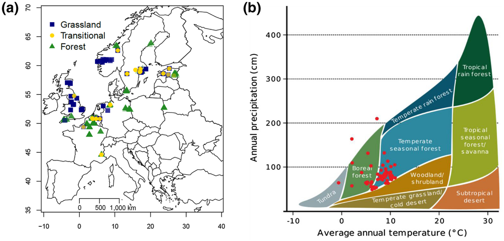

**FIGURE 1**

Location of the datasets. Geographic location in north‐western Europe (a) and Whittaker biome plot (b) of 54 presence–absence‐based herb layer–seed bank datasets, extracted from 41 published and 5 unpublished studies. The datasets capture the broad climatic variation in the temperate, Atlantic part of north‐western Europe, along with a land‐cover gradient from open grassland habitats (blue squares) over transitional habitats with developing canopies (yellow circles) towards mature, closed canopy forest habitats (green triangles)

## 2 MATERIALS AND METHODS

### 2.1 Data collection

#### 2.1.1 Herb layer and seed bank data

We used existing plant community data of 2,796 plots inventoried for both the herb layer (via plant relevés) and the seed bank (via greenhouse germination trials) from 54 datasets across a 2,250‐km latitudinal and 1,900‐km longitudinal gradient (Figure 1). The 54 datasets were derived from 41 published and 5 unpublished studies from NW Europe, compiled to span a range of land‐cover types (i.e. including studies investigating both single and multiple habitats) as well as a latitudinal climate gradient. The study of Plue et al. (2013) was divided into nine separate component datasets collected in distinct geographic regions along the studied latitudinal gradient. The five unpublished datasets were provided by Rob Marrs (two datasets), Robin Pakeman (one), Guillaume Decocq (one) and Jan Plue (one). For more details on data sources and a summary of the studies’ main characteristics, see Supporting Information Appendix S1: Data sources, and Table S1. From each dataset, we extracted the sampled surface area per plot for the herb layer [area of the relevé (m<sup>2</sup>)] and the seed bank [area of a single soil core × number of cores (m<sup>2</sup>)]. For ease of comparison and due to the frequent lack of abundance data, all herb layer and seed bank abundance data were transformed to presence–absence across studies. As only seed‐bearing plants are detectable via standard greenhouse germination trials of seed bank samples, cryptogams (do not produce seeds) and species of the family Orchidaceae (high level of fungal specificity during germination; Bidartondo & Read, 2008) were removed from the herb layer data. Similarly, as we were interested in the ground flora, trees (including tree‐like shrubs like *Corylus avellana*) were removed before analysis. Additional to herb layer and seed bank species richness, we calculated total species richness per plot as the sum of species either present in the herb layer or the seed bank, to test for environmental community responses not necessarily detectable in the herb layer or seed bank individually (Plue et al., 2017).

#### 2.1.2 Land cover and climate data

We used each study’s metadata to assign each plot to one of three land‐cover categories spanning the following continuum, representing one of the major ongoing directional shifts in land cover in Europe due to land abandonment of marginal lands (Buitenwerf et al., 2018; Kuemmerle et al., 2016; Song et al., 2018): (a) open grassland habitats represented mostly by managed semi‐natural grasslands (i.e. open habitats maintained via low‐intensity management such as mowing, cutting or grazing; *n* = 1,299); (b) transitional stages with a developing canopy, ranging from overgrown grasslands where the extensive management was recently abandoned, to young, post‐agricultural forests with a developing canopy (*n* = 890); and (c) mature, closed canopy forest habitats, represented mostly by old‐growth forests (*n* = 607). The various transitional stages such as abandoned semi‐natural grasslands and young, post‐agricultural forests were combined as they individually only provided discontinuous coverage of the entire climatic, latitudinal gradient. We recognize that there is substantial variation within each land‐cover type given differences in, for example, management intensity, forest stand age, grazing regime, etc., within and across the included studies. Attempts to refine these land‐cover types further based on, for example, ecosystem age or forest stand age would almost certainly create false precision while only being possible to calculate for a small subset of the data, supporting the use of these broad land‐cover types.

To characterize the local climate at each study plot, we downloaded the time series (1979–2013) climate data from the CHELSA database (Climatologies at High resolution for the Earth’s Land Surface Areas; https://chelsa‐climate.org/), including mean, minimum and maximum monthly temperatures and monthly precipitation at a 30 arc second resolution (Karger et al., 2017). These data were used to calculate mean annual temperature (°C), temperature annual range (°C) and total annual precipitation (mm) for each study plot, averaged across the 10 years up to and including the year of sampling. Plots sampled pre‐1988 (three datasets) were assigned 1979–1988 while plots sampled post‐2013 (one dataset) were assigned 2004–2013. Values were extracted using the *extract* function (*raster* R package; Hijmans, 2016). Temperature annual range represents the difference between the maximum temperature from the month with the warmest average temperature minus the minimum temperature in the month with the coolest average temperature, and was included (a) because of known importance for seed bank communities given that fluctuating temperatures are vital dormancy‐breaking and germination triggers (Hill & Vander Kloet, 2005; Plue et al., 2013) and (b) to investigate the effects of a flattening of annual temperature cycles. Flattening of annual temperature cycles, that is, the decrease of temporal variation of temperature over time, generally due to relatively more pronounced winter warming, has so far largely unknown consequences for plant community responses to climate change, though we know this variation to be key to numerous biological and ecological processes (Wang & Dillon, 2014). Ultimately, the geographic gradient combines space‐for‐time and space‐for‐warming substitution, an approach that can be used to carefully infer the potential future effects of changing land cover and climate on seed banks and their corresponding herb layer communities, respectively (Elmendorfer et al., 2015).

### 2.2 Data analysis

Seed banks are generally inventoried across *c*. 1% of the plot surface area in which the herb layer is surveyed (Vandvik et al., 2016). We therefore first investigate if there is a need to correct for the methodological disparity of herb layer and seed bank plot sampling in all ensuing climate–land‐cover models. Such a correction will ensure that herb layer and seed bank species richness are correctly evaluated and compared both across the included studies as well as between the herb layer and seed bank by correcting for skewed sampling efforts, enabling generalizations with a minimum of bias due to methodological limitations. Nevertheless, we are aware that such plot‐size correction could potentially distort some relationships under scrutiny. Vegetation ecological praxis indeed dictates that species‐rich communities should be sampled by means of smaller plots (and vice versa), based on differences in species–area relationships between habitats and/or biomes (see e.g. Kehoe et al., 2017). However, we believe this potential distortion is of limited concern to our study as (a) the range of plot sizes used is comparable across sampled land‐cover types (see Supporting Information Table S1), (b) this study is constrained to the temperate biomes, and (c) Vandvik et al. (2016) establish that for both the herb layer and seed bank specifically, species–area relationships are comparable for the broad land‐cover categories included here, which is the primary aim for the use of the plot‐size correction in order to support much‐needed generalizations on the importance of soil seed banks. Consequently, a constant plot‐size correction for sampling effort across all plots is the most appropriate for our study. This correction can be achieved via the inclusion of an offset term, that is, a known component of the linear predictor held constant while the explanatory variables are evaluated (Zuur et al., 2009). In this case, the offset would be based on the known linear relation between species richness and plot sampling effort. Therefore, given the range in plot sampling efforts for both the herb layer and the seed bank across datasets, we explored the methodological impact of plot sampling effort on herb layer and seed bank species richness. General linear models (GLMs) were used to test how herb layer and seed bank species richness were affected by their respective and log‐transformed plot and total core sampling area overall as well as within each land‐cover type. Similar GLMs were run for total species richness, which included the log‐transformed plot sampling area for the herb layer, log‐transformed total sampling area for the seed bank and their interaction. Besides identifying the need for a statistical sampling correction in the climate–land‐cover models, this procedure crucially identifies how seed bank species richness measures up to herb layer species richness at comparable sampling scales. GLMs were Gaussian‐error based, as all species richness variables were normally distributed.

with ^2 implying the inclusion of all two‐way interaction terms in the full model. Land cover was included as a categorical variable, with transitional land cover as the base factor for comparison against the two remaining categories. Three‐way and higher interaction terms were excluded for straightforward model interpretation. Dataset was included as a random effect to compensate for spatial autocorrelation. The major temperature gradient in the data is encapsulated within the latitudinal gradient (Figure 1). To ensure that any temperature signal would not be confounded by the various environmental variables that covary along the latitudinal gradient (soil conditions, photoperiod, etc.; De Frenne, Graae et al., 2013), we opted to include latitude as a fixed effect (only), to capture and remove unwanted, parallel latitudinal variation in species richness not attributable to temperature variation. However, as latitude and mean annual temperature were strongly correlated (*r*<sub>Pearson</sub> = −.77, *t* = −63.60, *p* < .001), they could not be reliably combined in the same model (Dormann et al., 2013). Latitude was hence included in the model as the residual variation in latitude after removal of latitudinal temperature variation. These residuals were extracted from a simple GLM with latitude as the dependent variable and mean annual temperature as the predictor variable only. Among the remaining climate and residual latitude predictor variables we recorded limited collinearity (mean|*r*<sub>Pearson</sub>| = .36, range between .09 and .64). This implies they can be safely combined into the mixed model to disentangle the impact of various predictor variables, though some collinearity bias cannot be entirely excluded (Dormann et al., 2013). Finally, the methodological sampling bias uncovered in the exploratory analysis between sampling effort and species richness was then compensated for in the climate–land‐cover models by the inclusion of an offset term. This offset term was log (herb layer sampling area^0.58) and log (seed bank sampling area^1.09) in the models on species richness in the herb layer and the seed bank, respectively. For the total species richness, the offset term was set as log((herb layer sampling area^0.54) × (seed bank sampling area^0.74)). The power values used were estimated a priori by running the models without an offset term, but with the sampling efforts as main effects in the model. The parameter estimates of the sampling areas then quantify the slope of the species—area relationship, which was then used as the power value in the offset term. Numerical dependent and predictor variables were scaled (*scale* function, base R functions) so that the model estimates for each predictor can be read as standardized effect sizes (SES). Through their standardization, the SES of each predictor term in the model (ranging between 0 and 1) are comparable both within and across models (Grueber et al., 2011) and help to establish the relative importance of each predictor across all predictors and models.

Compositional similarity between the herb layer and the seed bank is a common measure used to infer plant community responses to environmental changes and the potential for the seed bank to buffer or mediate such changes (Bossuyt & Honnay, 2008; Hille Ris Lambers et al., 2005; Hopfensperger, 2007). However, analyses have shown that patterns have in fact largely been influenced by sampling effort (Jabot & Pottier, 2017; Vandvik et al., 2016). Reanalysing a large number of seed bank datasets gives us the opportunity to correct for this effect and robustly analyse how similarity is driven by land cover and climate. To do so, we first needed to identify the herb layer–seed bank similarity metric that is least biased by differences in species richness between the herb layer and seed bank due to differences in their respective plot sampling efforts. Four commonly used similarity metrics were calculated per plot and per dataset using the *vegdist* and *raupcrick* functions from the *vegan* R package (Oksanen et al., 2016). The Jaccard and Bray–Curtis (also known as Sørensen) similarity metrics are most frequently used for quantifying herb layer–seed bank similarity yet carry known bias due to plot sampling effort. The Chao and Raup–Crick similarity metrics apply a mathematical and a species‐pool randomization approach, respectively, to reduce this plot sampling bias within studies (Chao et al., 2004; Raup & Crick, 1979). Gaussian‐based GLMs were used to test how each similarity metric depended upon the effect of herb layer sampling area, seed bank sampling area and their interaction, without model selection. Sampling efforts were not log‐transformed. However, the similarity indices were scaled (*scale* function; base R functions), so that the returned estimates of plot sampling efforts could be compared across models (also referred to further as standardized effect sizes or SES). The Raup–Crick similarity metric was least affected (albeit still significantly) by plot sampling efforts for both the seed bank and herb layer (SES<sub>SB</sub> = 3.38; *z* = 8.89; *p* < .001 and SES<sub>VG</sub> = −0.002; *z* = −6.44; *p* < .001). There was no significant effect of the interaction of herb layer and seed bank plot sampling efforts on the Raup–Crick similarity metric. The SES of herb layer sampling effort were identical for the Jaccard and Chao similarity metrics (SES<sub>VG</sub> Jaccard and Chao = −0.002), though Bray–Curtis was significantly more affected by sampling effort (SES<sub>VG</sub> Bray–Curtis = −0.003). The Raup–Crick similarity metric was, however, less affected by seed bank sampling effort than the other three similarity metrics (SES<sub>SB</sub> Jaccard, Bray–Curtis and Chao between 4.03 and 4.25). These results on Raup–Crick similarities being the metric least affected by plot sampling efforts were also evident in the analyses of the various similarity metrics within each land‐cover type (see Supporting Information Table S2). This metric was therefore used to assess the effects of land cover and climate on the compositional similarity between the herb layer and the seed bank communities. We used the modelling procedure as described earlier, with a Gaussian error distribution and the offset at logit (seed bank sampling area/herb layer sampling area) as a known predictor of the similarity metric. Models looking at the response of Raup–Crick similarity had a similar structure to those looking at species richness, with the exception that no a priori power estimates were made as the shape of the relationship between sampled area and the similarity index is not known. To follow a Gaussian distribution, the Chao and Raup–Crick similarity metrics were logit‐transformed before scaling. All analyses were performed in R 3.5 (R Development Core Team, 2017).

## 3 RESULTS

### 3.1 Diversity and community composition

We found seed banks to hold consistently more diversity than the herb layer across all three land‐cover types, after adjusting for sampling effort (Figure 2). Furthermore, there were rapid and significant increases in species richness in the seed bank with plot sampling effort compared to the herb layer, both overall [a 50% increase in sampling area corresponded to the detection of an extra 1.3 species in the seed bank compared to 0.67 in the herb layer, calculated as model estimate × log(1.5)], as well as separately in open habitats and mature, closed canopy forest (Figure 2; Supporting Information Table S2). The overall, mean Raup–Crick compositional similarity between the herb layer and seed bank without sampling correction and across land‐cover types was 51% [standard deviation (*SD*) ± 35%], suggesting high overall compositional resemblance between the seed bank and herb layer.

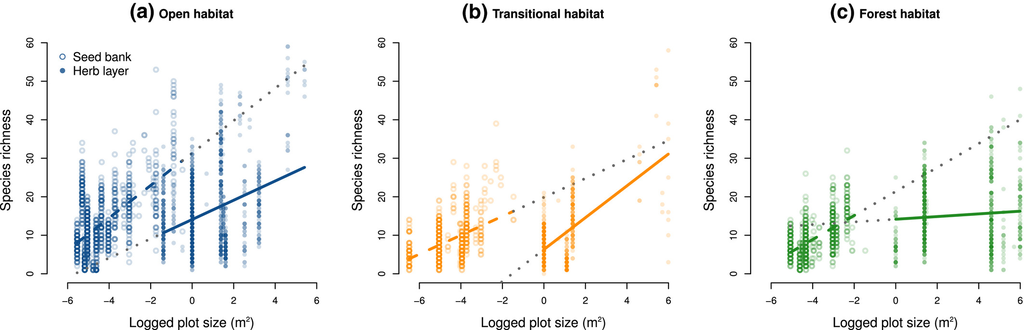

**FIGURE 2**

Species–area relationships of the soil seed bank and herb layer. Richness as a function of plot sampling effort for the seed bank (open circles) and the herb layer (closed circles) in open habitats (a), transitional habitats with a developing canopy (b) and mature, closed canopy forest habitats (c). Bold lines are the regression lines over the available range of the data for the seed bank (interrupted line) and the herb layer (full line), with the dotted grey lines visualizing extrapolation outside of their data ranges. Statistical output of the regressions can be found in Supporting Information Table S2

### 3.2 Effects of climate and land cover

The environmental gradients of land use and climate were directly associated with variation in species richness in the herb layer, seed bank and the combined plant community. The climate–land‐cover models, with a correction for plot sampling effort, showed how species richness in the herb layer was higher in open compared to intermediate habitats (SES = .71; *t* = 7.61; Figure 3a) and lower in plots with higher rainfall (SES<sub>Prec</sub> = −.73; *t* = −4.42). A significant positive interaction between mean annual temperature and temperature range implies a reinforcing effect of these climate variables on herb layer richness (SES = 0.14; *t* = 2.26). In other words, lower species richness in the herb layer in plots with a lower annual temperature range is especially pronounced in climates with higher mean annual temperatures, whereas this relationship is much weaker in cooler climates. There were also significant interactions with land use and climate in determining herb layer species richness. The negative effect of lower annual temperature range was stronger in both forest and open habitats than in intermediate habitats, while higher levels of precipitation were associated with lower richness in intermediate habitats compared to open habitats (Supporting Information Table S3).

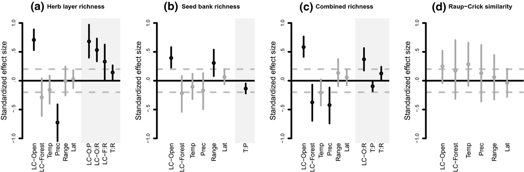

**FIGURE 3**

Effects of climate and land cover on species richness and compositional herb layer–seed bank similarity of plant communities. Standardized effect sizes (SES) of the climate and land‐cover predictor variables on species richness of the herb layer (a), the seed bank (b) and the combined plant community (c), as well as the Raup–Crick herb layer–seed bank compositional similarity (d). Circles mark the SES based on the full generalized linear mixed models with an offset to correct for plot sampling effort. Error bars mark the 95% confidence intervals. Black points highlight significant effects (zero does not fall within the confidence interval). The strength of the effect increases as the dot is further away from zero. Dashed horizontal lines delimit small from medium‐sized effects (SES < .2; Cohen, 1977). LC‐O = land cover, Open habitats; LC‐F = land cover, Mature, closed‐canopy forest habitats; T = mean annual temperature; R = temperature annual range; P = total annual precipitation. To avoid overly dense panels, only significant interactions are shown here (grey‐shaded area). Full model outputs can be found in Supporting Information Table S3

Species richness in the seed bank was also affected by land cover and climate, but smaller effect sizes imply that seed bank communities are less affected by environmental pressures. Seed bank species richness was again higher in open than in intermediate habitats, but to a lower extent (SES = .39, *t* = 4.35; Figure 3b, Supporting Information Table S3), while the negative effect of precipitation on richness was no longer significant (confidence intervals overlapped zero). Lower annual temperature ranges were associated with lower richness as a main effect in the seed bank (SES = .31, *t* = 2.54), as opposed to in the herb layer where this effect was dependent on other predictors. A negative interaction between mean annual temperature and total annual precipitation shows that negative effects of higher temperatures on seed bank richness were especially pronounced in plots with high precipitation.

Species richness of the combined plant community declined along the full land‐cover gradient from open to closed habitats (open: SES = .58, *t* = 6.44; forest: SES = −.38, *t* = −2.31; Figure 3c, Supporting Information Table S3), and decreased with increasing precipitation (SES = −.42, *t* = −2.63). The three significant interaction terms were among those recorded from the separate herb layer and seed bank models, but with generally reduced effect sizes. The effect of lower richness with increased temperature was more pronounced at plots with lower annual temperature ranges and those with higher annual precipitation, while there was a stronger negative effect of lower annual temperature range in open compared to intermediate habitats.

There were no significant environmental predictors of Raup–Crick compositional similarity between the herb layer and seed bank (Figure 3d, Supporting Information Table S3).

## 4 DISCUSSION

We found that warmer temperatures, higher precipitation, smaller annual temperature ranges and land cover all affected plant species richness in the herb layer and the seed bank, either directly or in interaction with other factors. However, the generally less‐pronounced combined plant community responses to climate and land cover compared to those of the herb layer alone suggest a potential buffering effect of the seed bank to the drivers of global environmental change. Despite these findings, this potential buffering capacity too appeared weakened in less variable climates and in increasingly wooded habitats.

Focusing first on species richness in the herb layer, our sub‐continental‐scale study supports previous findings that open grassland habitat contains more species in the flora than forests at the plot scale (Wilson et al., 2012), and those that report general losses in species richness as a result of abandonment of grassland management and subsequent secondary succession (Gerstner et al., 2014; Poschlod & WallisDeVries, 2002). Land cover also interacted with annual temperature range to determine plant species richness in the herb layer. The negative impact of a flatter temperature range was strongest in open habitats. The cooler and more stable microclimatic conditions provided by (developing) forest canopies may indeed mitigate the corresponding changing macroclimatic temperature range (Greiser et al., 2018; Morecroft et al., 1998), which can then be reflected in a limited impact of climate change on the composition of the herb layer in forests (De Frenne, Rodriguez‐Sanchez et al., 2013). At the same time, the negative effect of flatter temperature ranges was further strengthened where mean annual temperatures were higher. Were these effects to apply over time as well as across our geographic gradients, it would indicate a worrying bimodal impact of warming on physiological, biological and ecological processes (Wang & Dillon, 2014), which may in turn heighten the risks of future species extirpations.

While the herb layer is clearly affected by land cover, climate and interactions, the seed bank appears to demonstrate some capacity for buffering environmental pressures. Seed bank communities consistently held more species than the herb layer across land‐cover types (Figure 2), lending further support to the view that many species in the seed bank are either not visible or not captured during sampling (Hiiesalu et al., 2012; Plue et al., 2017; Vandvik et al., 2016). The higher species richness in the combined community may be a contributing factor to the smaller effect sizes of those environmental drivers that significantly affected seed bank richness (Figure 3). Seed bank species richness was unaffected by direct differences in mean annual temperature or annual rainfall regimes. Still, lower diversity related to lower annual temperature range and the much higher richness in open compared to intermediate habitats (Figure 3) lends large‐scale support for findings from individual studies associating reductions of seed bank species richness to land‐use change (Plue & Cousins, 2018) and a reduction in temperature range (Plue et al., 2013). Warmer temperatures were also associated with lower seed bank richness, at least where precipitation was relatively high. As temperature regimes affect all aspects of plant regeneration from seed longevity to dormancy release and germination (Walck et al., 2011), warmer climates will limit seed persistence, that is, the actual time a seed resides in the seed bank. As a result, despite being less affected than the herb layer, climate and land cover still negatively impacted the species richness of the seed bank. Nonetheless, by appearing to be less affected by land‐cover and climate variables than the herb layer, and with the combined plant community showing lower effect sizes than the herb layer alone (e.g. open habitat = 18% decrease, annual precipitation = 42% decrease, open habitat : temperature range interaction = 30% decrease; Figure 3), our results do suggest that seed banks may provide a potential buffer for plant community richness. Again, if we extend our results to look at the potential effects of change over time, it indicates that the seed bank may hold the potential to buffer the ongoing directional changes of grassland abandonment, increasing annual temperature and precipitation and flattening temperature ranges that are occurring across Europe. We also provide further evidence that assessments of environmental drivers on plant communities should ideally consider the whole community, including the seed bank, to improve estimates and projections of the true, net effects and rates of plant community changes in response to global changes.

Compositional similarity metrics are used within seed bank research to estimate the seed banks’ capacity to maintain the current established community. Using the Raup–Crick approach, we found high overall compositional similarity between the herb layer and the seed bank, suggesting that the seed bank may also buffer significant compositional changes in the herb layer in spite of substantial environmental variation. Our model did not reveal any significant effects of the land cover or climate variables tested. Therefore, after carefully selecting the similarity metric that is least affected by discrepancies in sampling effort between the herb layer and the seed bank, our results question the common finding that similarity decreases from open grassland to abandoned grassland and forest (Bossuyt & Honnay, 2008; Hopfensperger, 2007). Moreover, as compositional similarity was relatively stable at 40–60% along the sub‐continental gradient, seed bank communities not only reflect the herb layer to a significant degree, but our findings also suggest that the seed bank contains substantial numbers of habitat specialists in grasslands and forests, rather than a dominance of common generalist species (Vandvik et al., 2016).

Our large‐scale study, bringing together 2,796 corresponding herb layer and seed bank communities from across a large geographic gradient, shows that land cover and climate have clear effects on the richness and composition of plant communities. Our models showed that plant community richness was lower in areas with higher precipitation, lower annual temperature range and higher temperatures (at least where precipitation was relatively high), as well as in intermediate compared to open habitats. If the same patterns hold over time as well as across space, these results suggest that current trajectories of environmental change in Europe could strongly affect plant community diversity. However, such interpretations should always be treated with caution. Although large‐scale geographic gradients such as ours can be useful for making inferences about the broad direction of responses of ecological communities to past and future changes in their environment (Blois et al., 2013; De Frenne, Graae et al., 2013), the magnitude of these changes are much more difficult to infer (Elmendorfer et al., 2015; but see Damgaard, 2019). If the space‐for‐time/warming approach is valid in this case, our results can be seen as both positive and negative from the perspective of plant communities experiencing global change. Diverse seed banks, more so than the herb layer alone, may provide a significant buffer against the negative effects of climate and land‐use change in plant communities, both in terms of species richness and composition. By buffering plant community responses to global environmental changes, this provides a plausible mechanistic explanation as to why aboveground plant communities have been found to respond only slowly compared to the rapid and increasing rates of global environmental change, that is, so‐called extinction or climatic debts (e.g. Auffret et al., 2018; Bertrand et al., 2011; Halley et al., 2016). At larger spatial and temporal scales, these properties of seed banks can reduce a species’ extinction vulnerability under climate change and also contribute to climate‐driven range shifts (Estrada et al., 2015). Hence, though we cannot extrapolate the buffering effect’s size towards future plant community changes based on our space‐for‐warming approach, we are still convinced of its potential. Nonetheless, climate‐driven plant community changes are unavoidable. Negative and synergistic effects of the prevailing direction of global change towards warmer temperatures and a flattening of the annual temperature cycle (IPCC, 2014; Wang & Dillon, 2014), and a shift towards less‐open land cover (Buitenwerf et al., 2018; Song et al., 2018) on plant communities, including the seed bank, show how this capacity may be indeed limited in the future. Over the time‐horizon across which global environmental changes are expected to fully exert their biological and ecological impact, limited seed longevity in most species (Saatkamp et al., 2009; Telewski & Zeevaart, 2002) means that seed banks will most likely fail to offset the large effects of future changes in climate, land use and their interactions. These eventual negative effects on plant communities may then result in cascading losses of species richness at higher trophic levels, with consequences for ecosystem functioning (Isbell et al., 2011; Schleuning et al., 2016). Nonetheless, as novel plant communities arise under future climate regimes (Walther et al., 2002; Williams & Jackson, 2007), we expect that novel seed bank communities will also arise, continuing their evolutionary and ecological role as a storage and rescue mechanism to provide an environmental buffer for plant communities.

## ACKNOWLEDGMENTS

We thank all collaborators who helped collect the seed bank and vegetation data. JP was funded by the Foundation for Baltic Sea and Eastern European Studies (Östersjöstiftelsen) and a Future Research Grant (Swedish Research Council – Formas, 2018‐00961). AGA was funded by the Swedish Research Council – Formas (2015‐1065). GKP was funded by Natural Environment Research Council grant NE/D00036X/1, RJP was funded by the Scottish Government's Rural and Environmental Science and Analytical Services Division. UG was financially supported by the Swedish Natural Science Research Council. VV was funded by the Norwegian Research Council (grants 184912 and 73758/410). IA was funded by the Norwegian Research Council (grant 156325/530) SB was funded by the Programme Alβan, the European Union Programme of High‐Level Scholarships for Latin America (E07D400528CO) and Pontificia Universidad Javeriana (DJE‐009‐07). We are grateful for the constructive reviews provided by the handling editor, Dr Carsten Meyer, as well as two anonymous referees and Dr Sonja Wipf, which helped to improve the manuscript.

## AUTHOR CONTRIBUTIONS

JP & AGA conceived the project, built the consortium and wrote the paper. JP, AGA & HVC analysed data. All authors provided data, expertise, and commented during writing.

## Open Research

## Supporting Information

## REFERENCES

## BIOSKETCHES

Jan Plue is a landscape ecologist aiming to understand the mechanisms underpinning plant community responses to global change drivers, across spatial, temporal and biological scales. Alistair Auffret is a researcher in landscape ecology at the Swedish University of Agricultural Sciences. He is interested in the effects of climate and land‐use change on plant communities, using a range of different historical sources in his work. Together they built this consortium to tackle the role of temporal seed dispersal in plant community responses to global change.

January 2021

Pages 128-139

### Metrics

### Details

- © 2020 The Authors. Global Ecology and Biogeography published by John Wiley & Sons Ltd

  This is an open access article under the terms of the [Creative Commons Attribution](http://creativecommons.org/licenses/by/4.0/) License, which permits use, distribution and reproduction in any medium, provided the original work is properly cited.

[figure not shown]

### Research funding

  - Natural Environment Research Council. Grant Number: NE/D00036X/1
  - Norges Forskningsråd. Grant Numbers: 184912, 73758/410, 156325/530
  - Svenska Forskningsrådet Formas. Grant Numbers: 2015‐1065, 2018‐00961
  - Vetenskapsrådet
  - Scottish Government’s Rural and Environmental Science and Analytical Services Division
  - Östersjöstiftelsen

### Keywords

  - [climate change](https://onlinelibrary.wiley.com/action/doSearch?field1=Keyword&text1=climate%20change)
  - Europe
  - forest
  - grassland
  - [land‐use change](https://onlinelibrary.wiley.com/action/doSearch?field1=Keyword&text1=land%E2%80%90use%20change)
  - [plant biodiversity](https://onlinelibrary.wiley.com/action/doSearch?field1=Keyword&text1=plant%20biodiversity)
  - [soil seed bank](https://onlinelibrary.wiley.com/action/doSearch?field1=Keyword&text1=soil%20seed%20bank)

### Publication History

  - Issue Online: 16 December 2020
  - Version of Record online: 23 October 2020
  - Manuscript accepted: 17 September 2020
  - Manuscript revised: 15 September 2020
  - Manuscript received: 02 December 2019